# A Representative Sample of Australian Participant’s Attitudes Towards Government Tracking During the COVID-19 Pandemic.

Prof Simon Dennis, Mr Joshua White, Dr Paul Garrett, A/Prof Daniel Little, A/Prof Amy Perfors, Prof Yoshihisa Kashima, & Prof Stephan Lewandowsky

Complex Human Data Hub, School of Psychological Sciences, The University of Melbourne.

School of Psychological Sciences, The University of Bristol.

8 April 2020

# Background

The novel coronavirus or COVID-19 was declared a pandemic by the World Health Organization on March 11th, 2020 (World Health Organization, 2020). The COVID-19 virus transmits early in its life cycle relative to other coronaviruses, (e.g., SARS), during which time many individuals present as asymptomatic (Zhou et al., 2020). The moderate to high transmissibility of this virus has required governments to consider moderate to extreme measures in order to prevent further transmissions. Indeed, the nature of the COVID-19 pandemic may require governments to use big data technologies to help contain its spread (Bonsall, Parker, & Fraser, 2020).

Countries that have managed to “flatten the curve” - the process of slowing the exponential transmission rate of the virus, for example, Singapore and Taiwan - have employed collocation tracking through mobile Wi-Fi, GPS, and Bluetooth as a strategy to mitigate the impact of COVID-19 (Wang et al., 2020). Through collocation tracking, government agencies may observe who you have been in contact with and when this contact occurred, allowing for the rapid implementation of appropriate measures to reduce the spread of COVID-19.

The effectiveness of collocation tracking relies on the willingness of the population to support such measures, implying that government policy-making should be informed by the likelihood of public compliance. Gaining the social license - broad community acceptance beyond formal legal requirements - for collocation tracking requires the perceived public health benefits to outweigh concerns of personal privacy, security, and any potential risk of harm.

This report forms the preliminary results of a longitudinal cross-cultrual study mapping the evolution of people’s attitudes towards government tracking during the COVID-19 crisis. We aim to understand (1) the factors that influence the social license around governmental use of location tracking data in an emergency, (2) how this may change over time, and (3) how this may differ between countries.

The results we present here were collected through a representative survey of Australian residents that assessed their attitudes towards Government tracking during the COVID-19 pandemic. We presented participants with one of two scenarios describing different government tracking methods that may reduce the spread of COVID-19. We then question participants’ attitudes towards the proposed methods.

The two Government tracking scenarios differed in two important ways. In scenario one, participants could opt-in to being tracked by the Government and the collected data could only be used to contact those who may have been exposed to COVID-19. In scenario two, all people using a mobile phone would have their data tracked with no possibility to opt-out, and tracking data could be used to issue fines and arrests for violations of lockdown orders. The two scenarios are presented below:

## Scenario One

The COVID-19 pandemic has rapidly become a worldwide threat. Containing the virus’ spread is essential to minimise the impact on the healthcare system, the economy, and save many lives. The Australian Government might consider using smartphone tracking data to identify and contact those who may have been exposed to people with COVID-19. This would help reduce community spread by identifying those most at risk and allowing health services to be appropriately targeted. **Only people that downloaded a government app and agreed to be tracked and contacted would be included in the project.** The more people that download and use this app the more effectively the Government would be able to contain the spread of COVID-19. **Data would be stored in an encrypted format on a secure server accessible only to the Australian Government. Data would only be used to contact those who might have been exposed to COVID-19.**

## Scenario Two

The COVID-19 pandemic has rapidly become a worldwide threat. Containing the virus’ spread is essential to minimise the impact on the healthcare system, the economy, and save many lives. The Australian Government might consider using phone tracking data supplied by telecommunication companies to identify and contact those who may have been exposed to people with COVID-19. This would help reduce community spread by identifying those most at risk and allowing health services to be appropriately targeted. **All people using a mobile phone would be included in the project, with no possibility to opt-out.** Data would be stored in an encrypted format on a secure server accessible only to **the Australian Government who may use the data to locate people who were violating lockdown orders and enforce them with fines and arrests where necessary.** Data would also be used to inform the appropriate public health response and to contact those who might have been exposed to COVID-19, and individual quarantine orders could be made on the basis of this data.

# Results

## Status of the initial data collected

These results represent a snapshot from the first 1147 participants collected for the project, Establishing the social licence for Government tracking in Australia. This representative sample was gathered through the data collection platform Dynata.

Notes on cleaning the data.

1. The second and third rows of the raw CSV file were deleted before analysis. These rows contained header information that interferred with loading into R.
2. Seventeen participants were removed prior to analysis for indicating a country of residence other than Australia.
3. Four participants were removed prior to analysis for indicating they were below the age of 18.
4. 239 participants did not pass the attention check.
5. 96 participants did not complete the survey.

The final sample for analysis was 791 participants.

# Descriptive Statistics

Gender was evenly divided between men and women. Within our sample, participants most frequently reported as having a university education (52%) or a higher school education (39%). Ages ranged from 18 years to 89 years (M = 49 years, SD = 17 years). The distribution of reported ages was uniform within the age range 20–80, and under represented for ages 80+.

| Gender identification: Percentages | Gender identification: Percentages #Total |
| --- | --- |
| Gender |  |
| Men | 52.8 |
| Women | 47.0 |
| Other | 0.1 |
| Prefer not to say |  |
| #Total cases | 791 |

| Level of education: Percentages | Level of education: Percentages #Total |
| --- | --- |
| Education |  |
| < High School | 9.2 |
| High School | 38.7 |
| University | 52.1 |
| #Total cases | 791 |

Distribution of ages.

```
## Descriptive Statistics
## COVIDdata$age
## N: 791
##
##                        age
## ----------------- --------
##              Mean    48.96
##           Std.Dev    17.48
##               Min    18.00
##                Q1    34.00
##            Median    49.00
##                Q3    64.00
##               Max    89.00
##               MAD    22.24
##               IQR    30.00
##                CV     0.36
##          Skewness     0.04
##       SE.Skewness     0.09
##          Kurtosis    -1.13
##           N.Valid   791.00
##         Pct.Valid   100.00
```

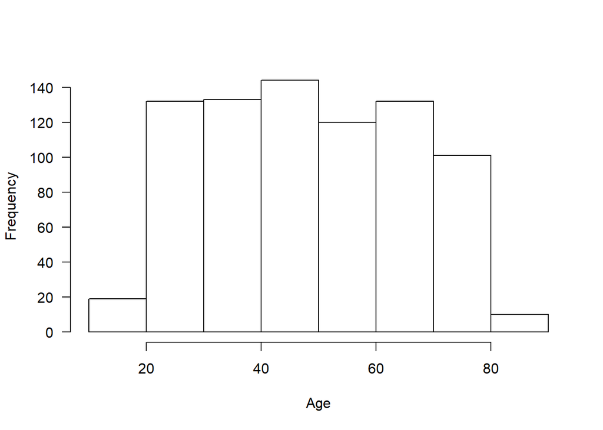

# Impacts of COVID

Participants reported as being under lockdown for an average of 13 (SD = 12) days, with the most frequent amount of time in lockdown reported as zero days (n = 170; 22%). Nineteen percent of participants reported as having lost their job due to COVID-19. The most common source of COVID-19 information came from TV (56%) and newspaper (21%), followed by social media (13%). Of the 791 participants, five (0.6%) reported that they had tested positive with COVID-19, and 47 (6%) indicated they knew someone who had tested positive with COVID-19.

[figure not shown]

| I have lost my job: Percentages | I have lost my job: Percentages #Total |
| --- | --- |
| I lost my job |  |
| No | 81.5 |
| Yes | 18.5 |
| #Total cases | 791 |

| Information source: Percentages | Information source: Percentages #Total |
| --- | --- |
| Information source |  |
| Newspaper (printed or online) | 20.6 |
| Social media | 12.6 |
| Friends/family | 3.0 |
| Radio | 3.8 |
| Television | 55.6 |
| Other | 4.3 |
| #Total cases | 791 |

| Somebody I know tested positive for COVID-19: Percentages | Somebody I know tested positive for COVID-19: Percentages #Total |
| --- | --- |
| Tested pos someone I know |  |
| No | 94.1 |
| Yes | 5.9 |
| #Total cases | 791 |

```r
hist(COVIDdata$COVID_ndays_4, xlab="Days in `lockdown`",main="",  breaks = 50)
```

# Perceived Risk of COVID

When asked about COVID-19 within the Australian population, participants most frequently reported the virus to be moderate in severity and that the virus posed a somewhat harmful risk to their personal health. Responses were both normally distributed around these moderate values.

When asked about their concern over testing positive to COVID-19, participants were normally distributed and centered on moderatly concerned. When asked about their concern over someone they know testing positive to COVID-19, participants responses were negatively skewed, showing a bias in their concerned for the health of others. A strong correlation was observed between concern for others and concern for self (r = .78), and between risk of personal harm and concern for self (r = .63).

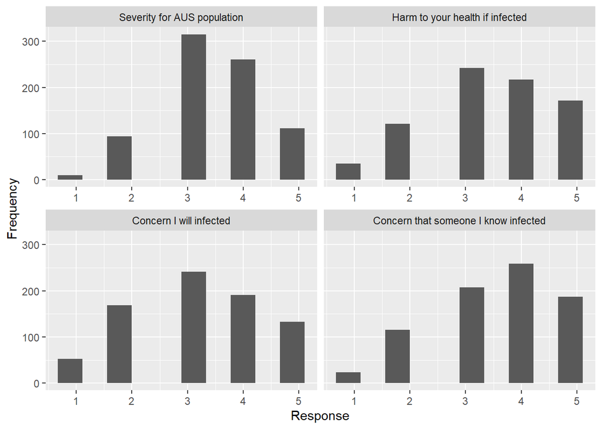

```
##                    COVID_gen_harm COVID_pers_harm COVID_pers_concern
## COVID_gen_harm              1.000           0.465              0.524
## COVID_pers_harm             0.465           1.000              0.630
## COVID_pers_concern          0.524           0.630              1.000
## COVID_concern_oth           0.498           0.502              0.779
##                    COVID_concern_oth
## COVID_gen_harm                 0.498
## COVID_pers_harm                0.502
## COVID_pers_concern             0.779
## COVID_concern_oth              1.000
```

# Perceived Impact of Government Tracking

The following violine plots characterizes participant’s confidence that in each scenario Government tracking would:

1. Reduce their likelihood of contracting COVID-19
2. Allow them to resume their normal lives more rapidly
3. Reduce spread of COVID-19 in the community.

Participants were more confident that they would not contract COVID-19 and that they would resume their normal activities under scenario two. Participants were confident that both scenarios would reduce the spread of COVID-19.

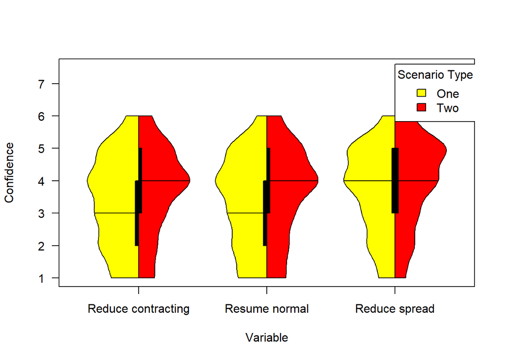

## Acceptability of Government Tracking

|  |  |  | #Total |
| --- | --- | --- | --- |
| Scenario Type |  |  |  |
| Scenario One | Acceptability of policy | No | 30.2 |
|  |  | Yes | 69.8 |
|  |  | #Total cases | 401 |
| Scenario Two | Acceptability of policy | No | 21.0 |
|  |  | Yes | 79.0 |
|  |  | #Total cases | 390 |

```
##
##  Pearson's Chi-squared test with Yates' continuity correction
##
## data:  unlabel(accept1$value) and unlabel(accept1$key)
## X-squared = 8.2017, df = 1, p-value = 0.004185
```

|  |  |  | #Total |
| --- | --- | --- | --- |
| Scenario Type |  |  |  |
| Scenario One | Acceptability of policy | No | 32.9 |
|  |  | Yes | 67.1 |
|  |  | #Total cases | 401 |
| Scenario Two | Acceptability of policy | No | 25.4 |
|  |  | Yes | 74.6 |
|  |  | #Total cases | 390 |

```
##
##  Pearson's Chi-squared test with Yates' continuity correction
##
## data:  unlabel(accept2$value) and unlabel(accept2$key)
## X-squared = 5.0684, df = 1, p-value = 0.02437
```

## Conditional Acceptance of Government Tracking

The following results were collected from those people who indicated that they would not download the app (scenario one) or who indicated that Government tracking was not acceptable (scenario two).

|  |  |  | #Total |
| --- | --- | --- | --- |
| Scenario Type |  |  |  |
| Scenario One | Acceptability with sunset | No | 78.0 |
|  |  | Yes | 22.0 |
|  |  | #Total cases | 132 |
| Scenario Two | Acceptability with sunset | No | 59.6 |
|  |  | Yes | 40.4 |
|  |  | #Total cases | 99 |

The following tables describe acceptability of Government tracking if i) the tracking data were to stay on the phone and only be uploaded with the consent of the individual (scenario one only), and ii) if participants were able to opt-in to the data collection (scenario two only).

|  | #Total |
| --- | --- |
| Acceptability with local storage |  |
| No | 64.4 |
| Yes | 35.6 |
| #Total cases | 132 |

|  | #Total |
| --- | --- |
| Acceptability with opt out |  |
| No | 39.4 |
| Yes | 60.6 |
| #Total cases | 99 |

These responses were combined into a quasi-interval scale using the following coding scheme: YES=acceptable; NO=not acceptable unless sunset or optout; -1=not acceptable unless the inclusion of sunset or opt-out (but not both); -2=not acceptable under any circumstances

|  | #Total |
| --- | --- |
| Acceptability of policy |  |
| -2 | 14.5 |
| -1 | 7.1 |
| No | 7.6 |
| Yes | 70.8 |
| #Total cases | 791 |

The next graph shows responses to the following items (abridged from survey):

1. How easy is it for people to decline participation in the proposed project?
2. To what extent is the Government only collecting the data necessary?
3. How sensitive is the data being collected in the proposed project?
4. How serious is the risk of harm that could arise from the proposed project?
5. How much do you trust the Government to use the tracking data only to deal with the COVID-19 pandemic?
6. How much do you trust the Government to be able to ensure the privacy of each individual?
7. How secure is the data that would be collected for the proposed project?
8. To what extent do people have ongoing control of their data?

The following results hold across both scenario one and scenario two. Participants generally displayed a high degree of Government trust and indicated that the Government was only collecting data necessary for COVID-19 tracing. Participants generally believed that the Government would ensure their privacy and secure their data. Although participants did not view the risk of harm in collecting this data as particularly high, they did understand that the data collected was sensitive (i.e., in need of security and privacy).

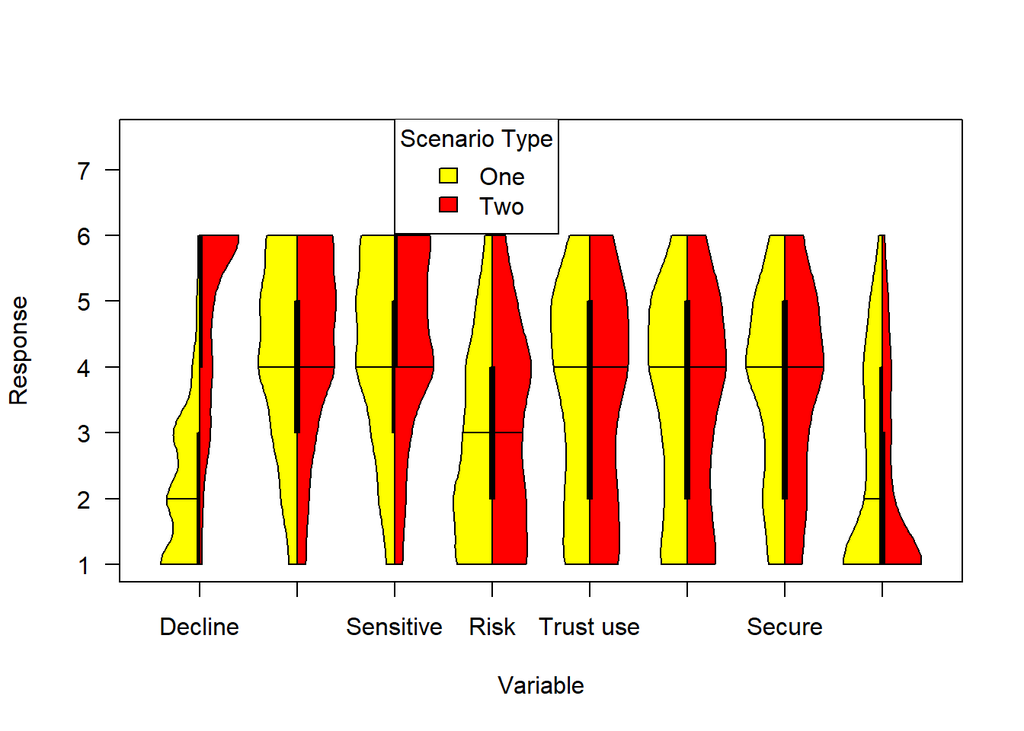

# References

Bonsall, D., Parker, M., Fraser, C. (2020).Sustainable containment of COVID-19 using smartphones in China: Scientific and ethical underpinnings for implementation of similar approaches in other settings.

The world health organization (WHO). WHO announces COVID-19 outbreak a pandemic. Retrieved from http://www.euro.who.int/en/health-topics/health-emergencies/coronavirus-covid-19/news/news/2020/3/who-announces-covid-19-outbreak-a-pandemic.

Wang, C. J., Ng, C. Y., & Brook, R. H. (2020). Response to COVID-19 in Taiwan: big data analytics, new technology, and proactive testing. JAMA.

Zhou, T., Liu, Q., Yang, Z., Liao, J., Yang, K., Bai, W., … & Zhang, W. (2020). Preliminary prediction of the basic reproduction number of the Wuhan novel coronavirus 2019-nCoV. Journal of Evidence-Based Medicine.